# 0609_Time series final report

以時間序列分析美國政府升息政策是否造成核心通膨率下降?

- 研究期間: 1990年1月 ~ 2017年12月
- 資料來源: FRED

```r
setwd("D:/Chang-web/data")
library(readr)
corecpi <- read_csv("CPILFENS_1990-2017.csv", show_col_types = F)
colnames(corecpi) <- c("date", "cpi")
```

- 原始資料時間序列圖

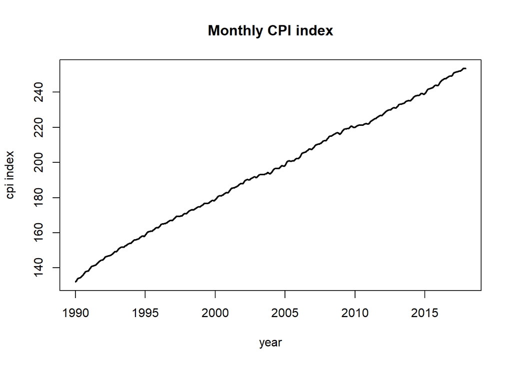

```r
cpi <- ts(corecpi$cpi, start=c(1990,1),end=c(2017,12),frequency=12)
plot(cpi, xlab="year", ylab="cpi index", main = "Monthly CPI index", lwd = 2)
```

### 壹、資料前處理

- 除了讓時間數列更為平穩，因為是要觀察核心通膨率，所以對 CPI 取 log，再開始處理並進行分析。

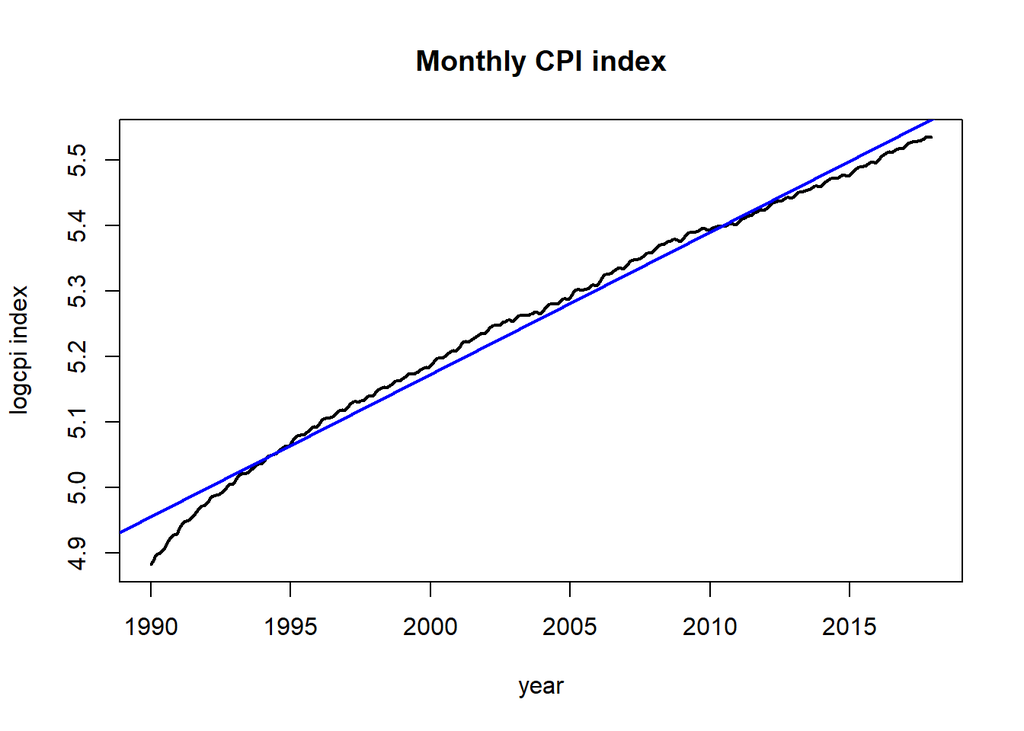

```r
corelogcpi <- data.frame("date" = corecpi$date, "logcpi" = log(corecpi$cpi))
logcpi <- ts(corelogcpi$logcpi, start=c(1990,1),end=c(2017,12),frequency=12)
# 取對數後的時間序列圖，有時間趨勢
plot(logcpi, xlab="year", ylab="logcpi index", main = "Monthly CPI index", lwd = 2);abline(reg = lm(logcpi ~ time(logcpi)), col = "blue", lwd = 2) # time trend
```

### 貳、資料分割_訓練與測試集

切割標準為聯準會在2006年後的首度升息2015年12月，因為接近年底，以2016年1月為分割點。

- 訓練集1990年1月 ~ 2015年12月(共312筆資料)
- 測試集2016年1月 ~ 2017年12月(共24筆資料)
- 因為2019年後的疫情，經濟數據變動可能受到其他外生因素干擾，會影響預測結果，因此取較早的升息時間點做本次報告的分析。
- 測試集原先只需要取5 ~ 10筆，但因為政策對經濟的影響有時間延滯，所以增加測試集區間為2年(24筆)。

```r
corecpi_train <- corelogcpi[-c(313:336), ]
corecpi_test <- corelogcpi[313:336, ]
str(corecpi_train)
```

```
## 'data.frame':    312 obs. of  2 variables:
##  $ date  : Date, format: "1990-01-01" "1990-02-01" ...
##  $ logcpi: num  4.88 4.89 4.9 4.9 4.9 ...
```

```r
logcpi <- ts(corecpi_train$logcpi, start=c(1990,1),end=c(2015,12), frequency = 12)
library(astsa)
logcpiacf2 <- acf2(logcpi, max.lag = 100) # acf: slow decay
```

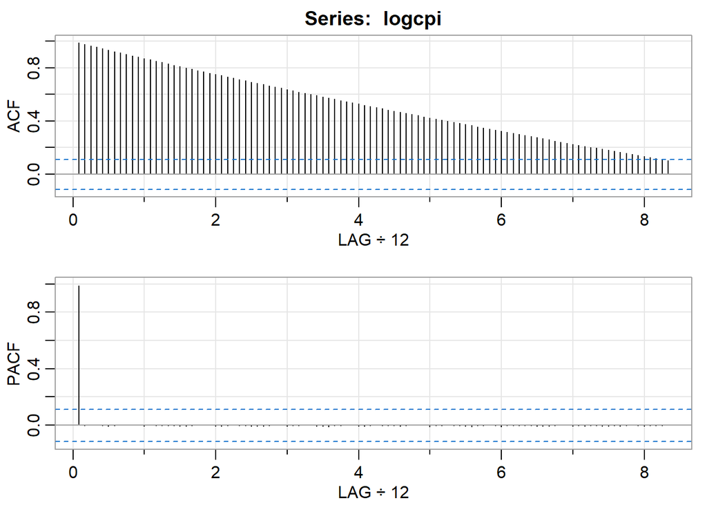

### 參、分析流程

- 方法一、差分處理
  - 1. 有時間趨勢，取一階差分

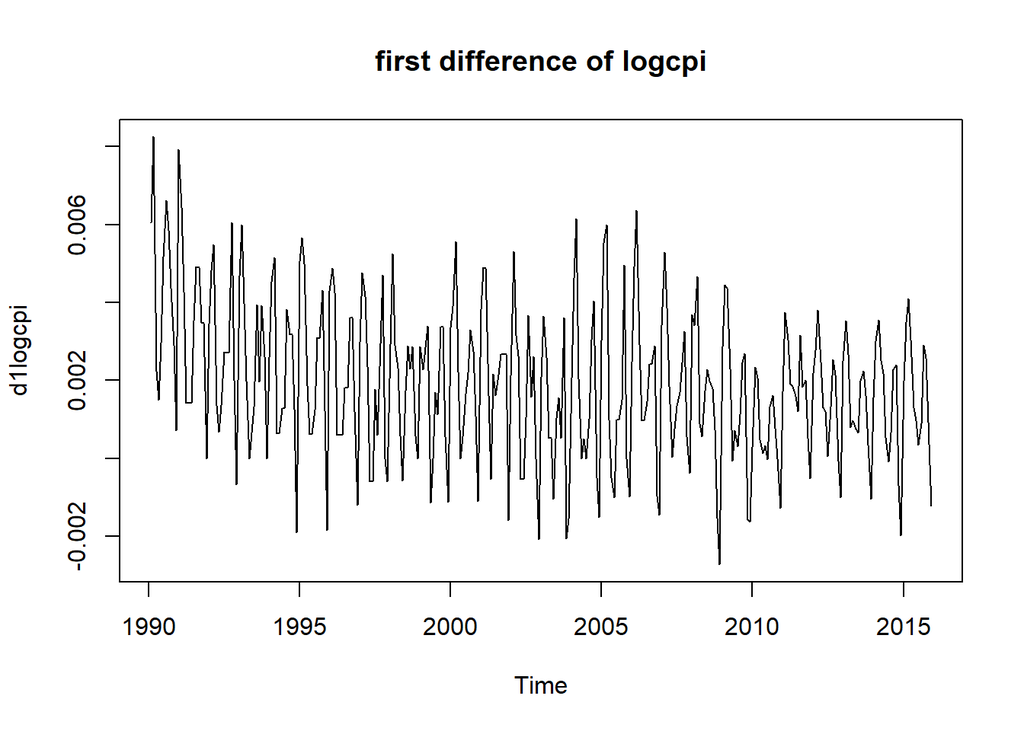

```r
d1logcpi <- diff(logcpi, 1)
ts.plot(d1logcpi, main = "first difference of logcpi")
# 此序列雖然沒有考慮季節性差分，因為已經是定態，所以我們還是對其配適模型
library(tseries)
```

```r
adf.test(d1logcpi) # stationary
```

```
##
##  Augmented Dickey-Fuller Test
##
## data:  d1logcpi
## Dickey-Fuller = -5.2699, Lag order = 6, p-value = 0.01
## alternative hypothesis: stationary
```

- 方法一、差分處理
  - 2. 一階差分後，季節性部分acf緩慢遞減，再取一階lag = 12之季節性差分

```r
d1logcpiacf <- acf2(d1logcpi,  max.lag = 180)
```

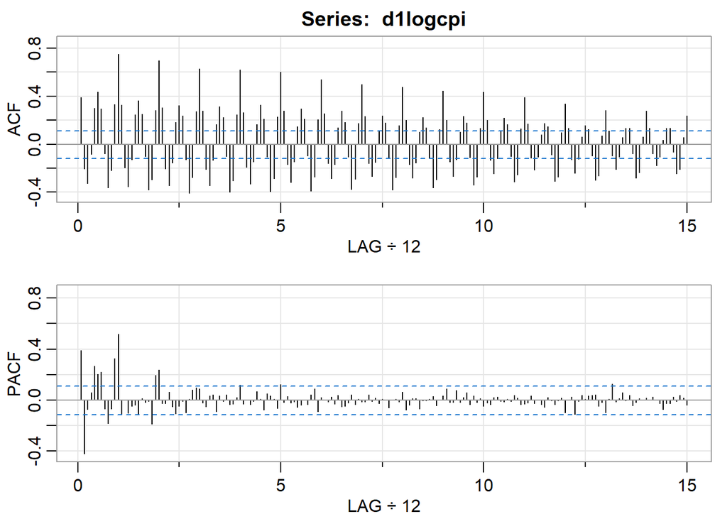

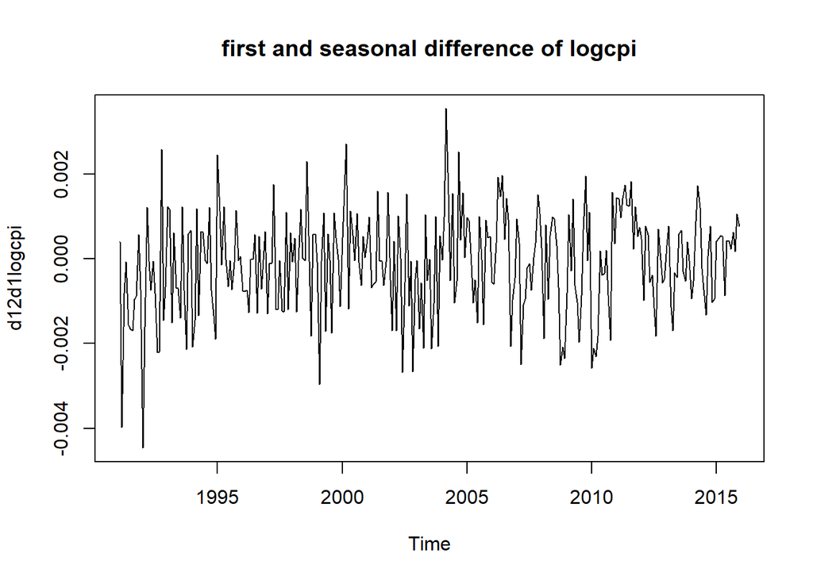

```r
d12d1logcpi <- diff(d1logcpi, 12)
ts.plot(d12d1logcpi, main = "first and seasonal difference of logcpi")
```

```r
d12d1logcpiacf <- acf2(d12d1logcpi,  max.lag = 150) # 沒有明顯趨勢，不須再做差分
```

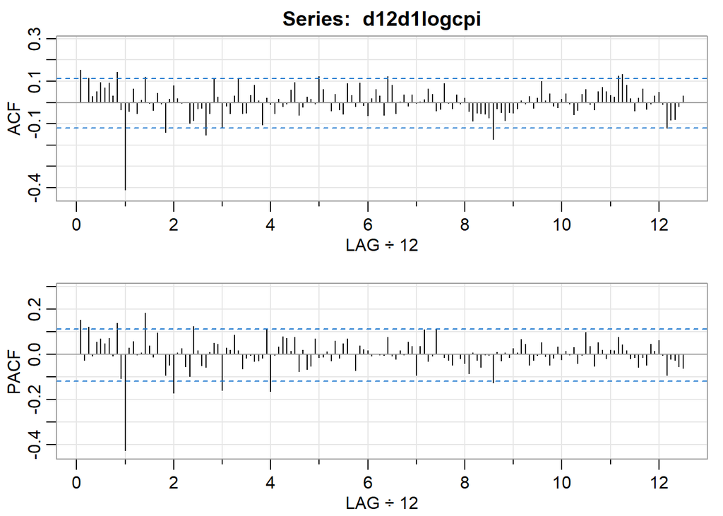

```r
adf.test(d12d1logcpi) # stationary
```

```
##
##  Augmented Dickey-Fuller Test
##
## data:  d12d1logcpi
## Dickey-Fuller = -5.4805, Lag order = 6, p-value = 0.01
## alternative hypothesis: stationary
```

- 方法二、以時間t作為變數之迴歸處理
  - 先去除CPI增長的趨勢，使用時間t作為迴歸變數，得到的fitted values計算殘差，觀察殘差時間序列圖，再取適當的差分。
  - 我們發現 d12d1res1 和 d12d1logcpi 的 acf, pacf 相同，但因為是從不同方式得到的序列，且後續計算PMSE的方式也相異，因此雖然配適模型order選取相同，仍視為兩種情形。

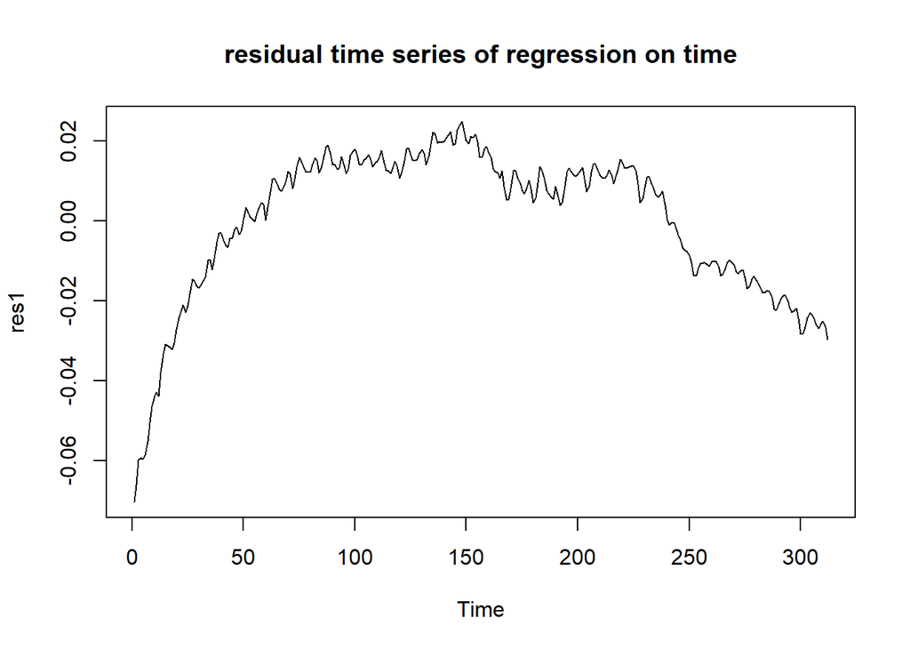

```r
t <- 1:312
reg1 <- lm(logcpi ~ 1 + t, data = corecpi_train)
res1 <- reg1$residuals
ts.plot(res1, main = "residual time series of regression on time")
```

```r
res1acf <- acf2(res1, max.lag = 100)  # res1的acf有緩慢遞減，對其取一階差分
```

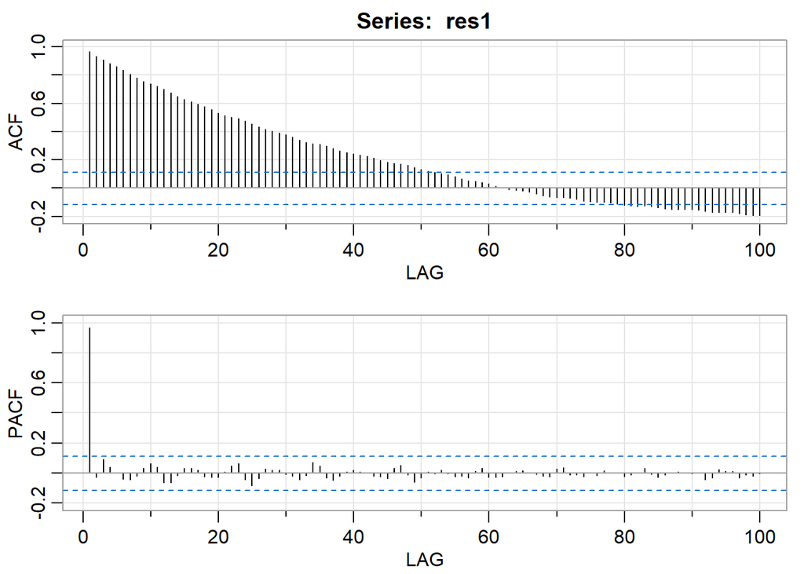

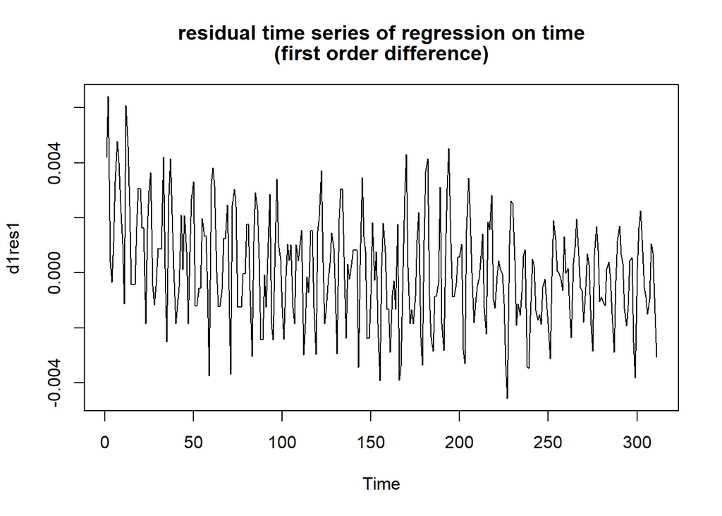

```r
d1res1 <- diff(res1, 1)
ts.plot(d1res1, main = c(paste("residual time series of regression on time"),
                         paste("(first order difference)")))
```

```r
# 一階差分後，季節性部分緩慢遞減，再取一階lag = 12之季節性差分
d1res1acf <- acf2(d1res1, max.lag = 180)
```

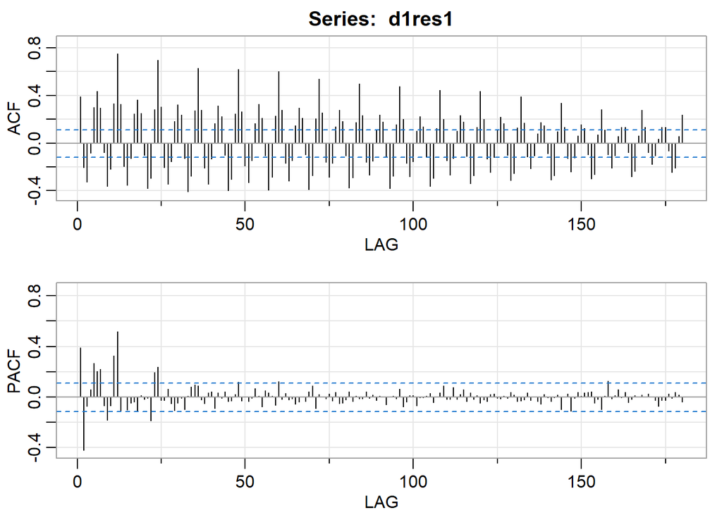

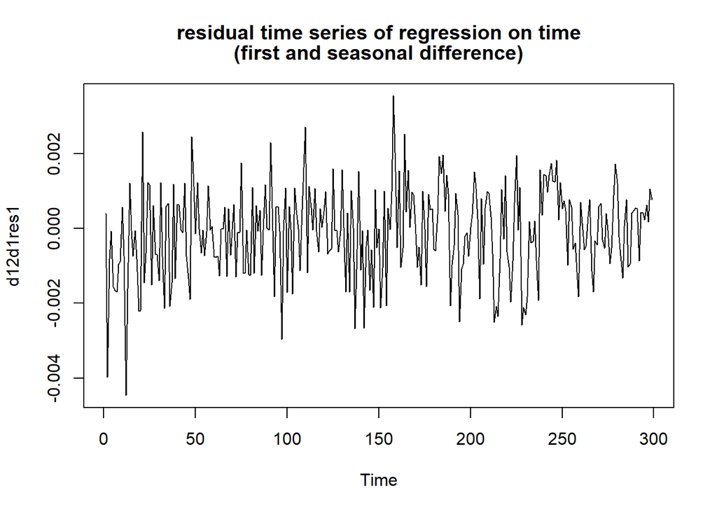

```r
d12d1res1 <- diff(d1res1, 12)
ts.plot(d12d1res1, main = c(paste("residual time series of regression on time"),
                         paste("(first and seasonal difference)")))
```

```r
d12d1res1acf <- acf2(d12d1res1, max.lag = 150) # 沒有明顯趨勢，不須再做差分
```

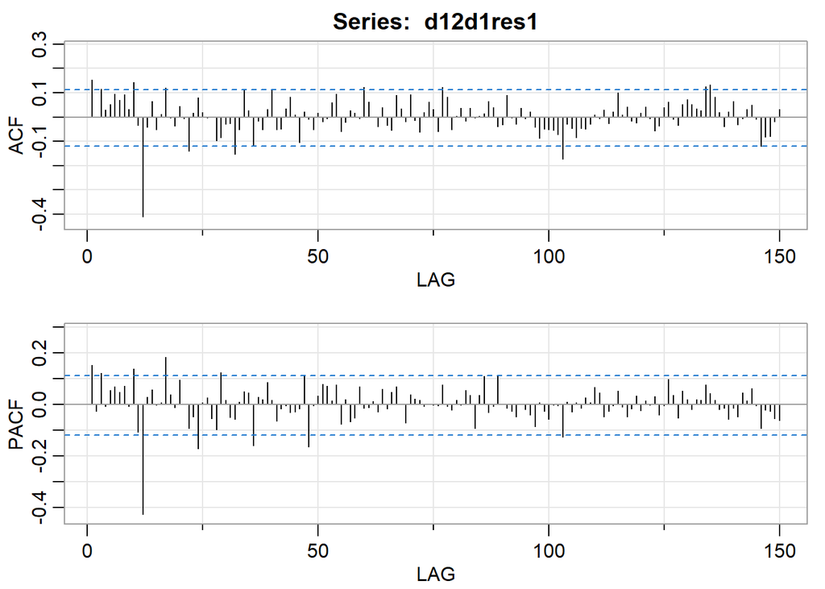

```r
adf.test(d12d1res1) # stationary
```

```
##
##  Augmented Dickey-Fuller Test
##
## data:  d12d1res1
## Dickey-Fuller = -5.4805, Lag order = 6, p-value = 0.01
## alternative hypothesis: stationary
```

- 方法三、多變量迴歸處理
  - 使用 IPI 和 UE 作為迴歸變數，觀察得到殘差的時間序列圖，再取適當的差分。

```r
setwd("D:/NCCU/double major and minor/Statistics/time series analysis/report/data")
### 次要變數一: 工業生產指數 industry production index
ipi <- read_csv("IPI_1990-2017.csv", show_col_types = F)
## train and test set
ipi_train <- ipi[-c(313:336), ]
### 次要變數二: 失業率 unemployment rate
ue <-  read_csv("UE_1990-2017.csv", show_col_types = F)
### train and test set
ue_train <- ue[-c(313:336), ]
traindata <- data.frame(corecpi_train, IPI = ipi_train$IPB50001N, UE = ue_train$UNRATENSA)
str(traindata)  # 全部都是數值型變數
```

```
## 'data.frame':    312 obs. of  4 variables:
##  $ date  : Date, format: "1990-01-01" "1990-02-01" ...
##  $ logcpi: num  4.88 4.89 4.9 4.9 4.9 ...
##  $ IPI   : num  61.6 62.6 62.9 61.6 62.2 ...
##  $ UE    : num  6 5.9 5.5 5.3 5.2 5.4 5.6 5.5 5.6 5.5 ...
```

- 方法三、多變量迴歸處理
  - 多變量迴歸處理 a. 此迴歸殘差序列非定態，但因為ACF沒有緩慢遞減，我們嘗試對其建模。

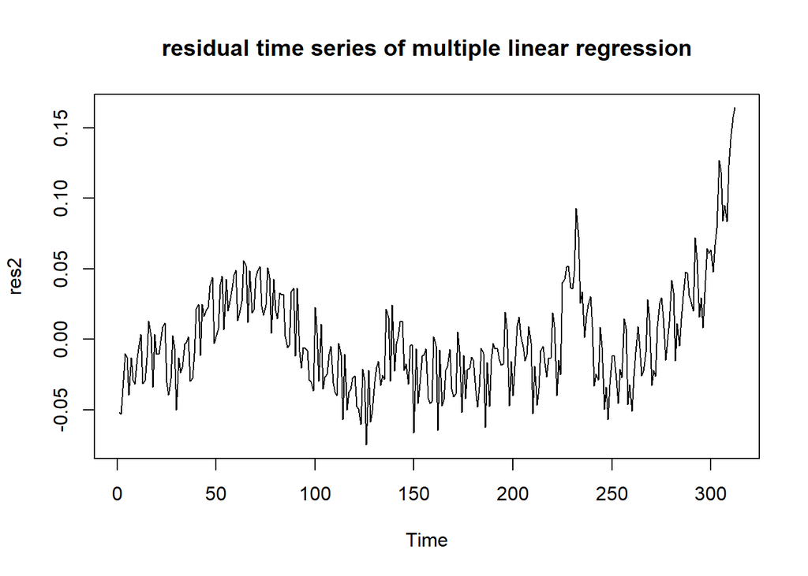

```r
reg2 <- lm(logcpi ~ IPI + UE, data = traindata)
res2 <- reg2$residuals
ts.plot(res2, main = "residual time series of multiple linear regression")
```

```r
res2acf <- acf2(res2, max.lag = 100)
```

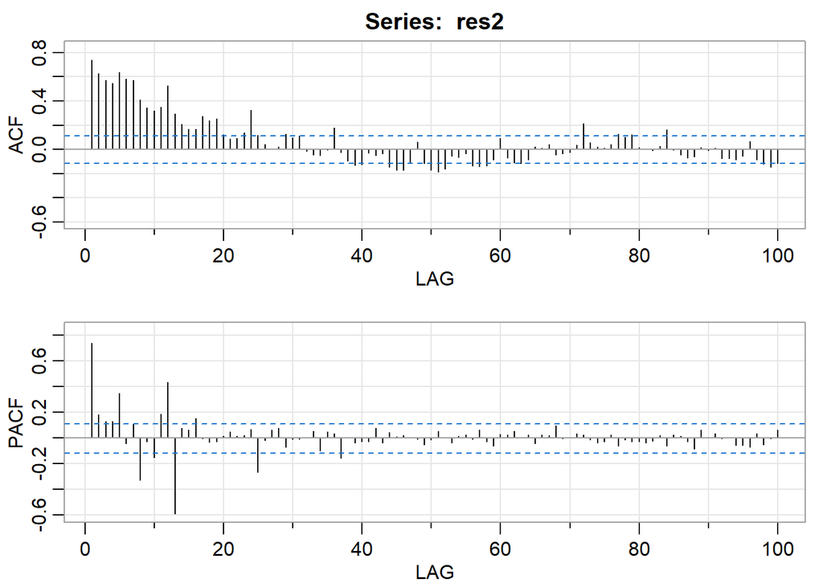

```r
adf.test(res2) # not stationary
```

```
##
##  Augmented Dickey-Fuller Test
##
## data:  res2
## Dickey-Fuller = 0.90758, Lag order = 6, p-value = 0.99
## alternative hypothesis: stationary
```

- 方法三、多變量迴歸處理
  - 多變量迴歸處理 b.

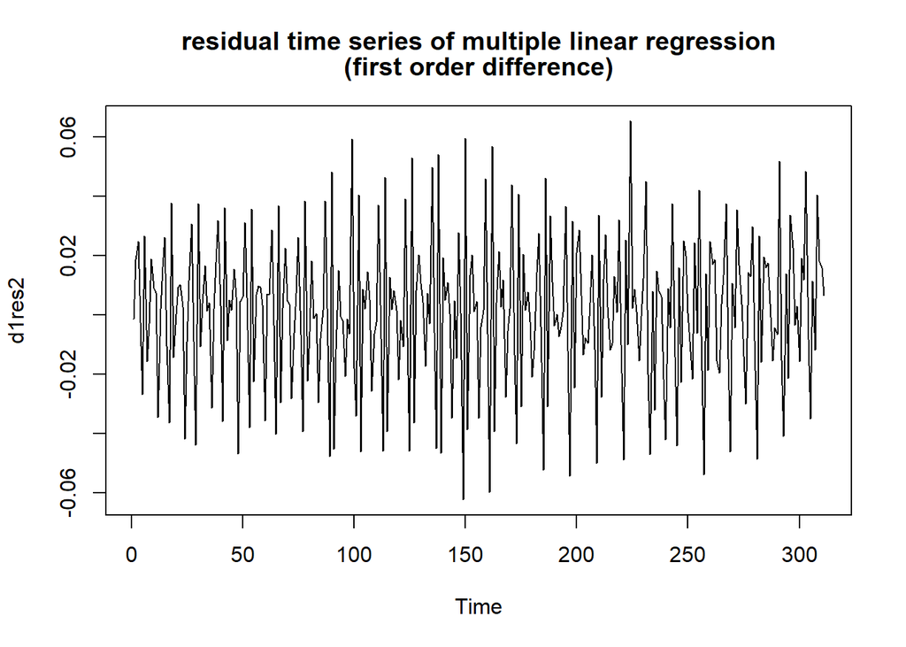

```r
# 迴歸殘差序列非定態，且時間序列圖還有些上升的趨勢，考慮一階差分
d1res2 <- diff(res2, 1)
ts.plot(d1res2, main = c(paste("residual time series of multiple linear regression"),
                         paste("(first order difference)")))
```

```r
d1res2acf <- acf2(d1res2, max.lag = 180)
```

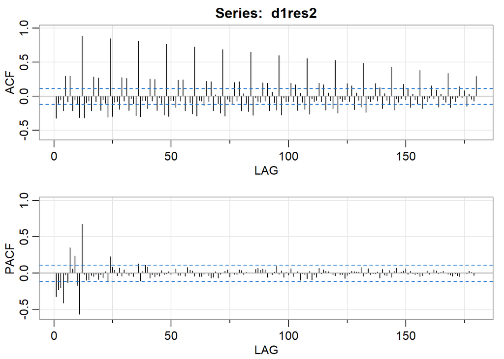

```r
adf.test(d1res2)
```

```
##
##  Augmented Dickey-Fuller Test
##
## data:  d1res2
## Dickey-Fuller = -6.7982, Lag order = 6, p-value = 0.01
## alternative hypothesis: stationary
```

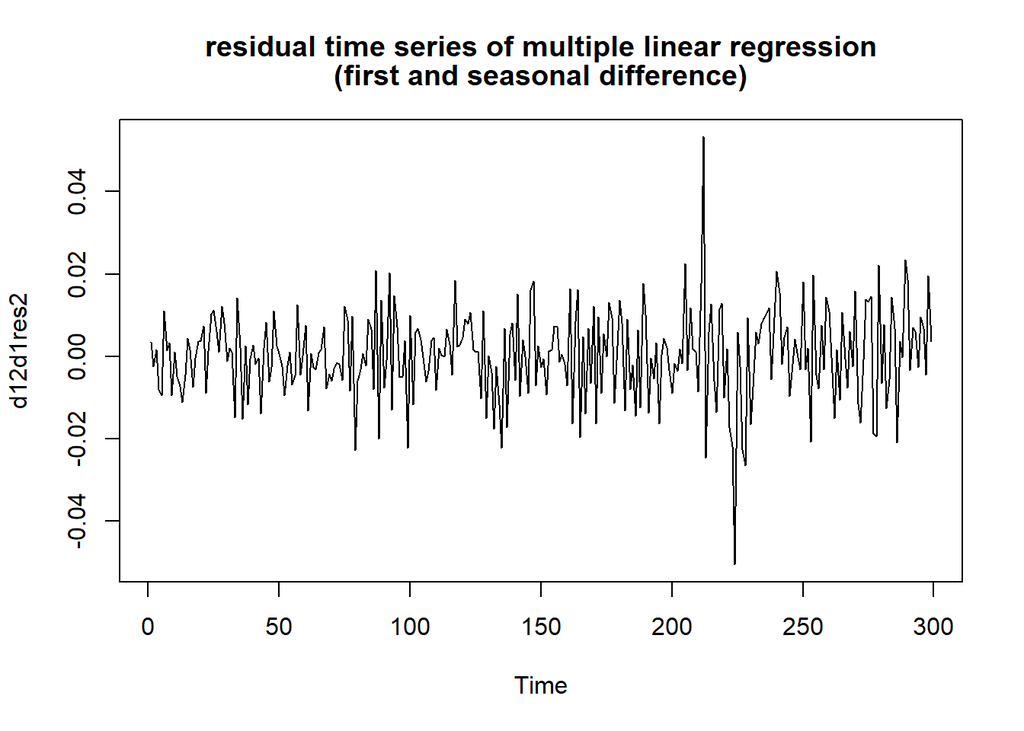

```r
# 一階差分為定態序列，但是acf在seasonal有緩慢遞減的現象，考慮再一次季節性差分
d12d1res2 <- diff(d1res2, 12)
# 此迴歸殘差序列沒有明顯的趨勢，不須再差分。
ts.plot(d12d1res2, main = c(paste("residual time series of multiple linear regression"),
                         paste("(first and seasonal difference)")))
```

```r
d12d1res2acf <- acf2(d12d1res2, max.lag = 150)
```

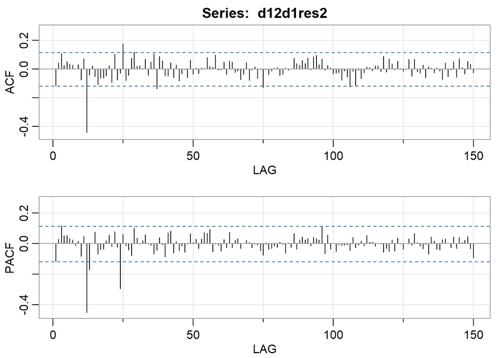

```r
adf.test(d12d1res2) # stationary
```

```
##
##  Augmented Dickey-Fuller Test
##
## data:  d12d1res2
## Dickey-Fuller = -5.3198, Lag order = 6, p-value = 0.01
## alternative hypothesis: stationary
```

### 肆、建立 SARIMA 模型

- 分別對四種序列(方法一:a.b.; 方法三:a.b.)建立 SARIMA 模型: 畫出acf和pacf，決定order
- 方法一、二之時間數列圖都在 0 附近震盪，所以配適模型皆不考慮估計常數項
- 方法一、差分處理 a.

```r
d1logcpiacf2 <- acf2(d1logcpi, max.lag = 150)
```

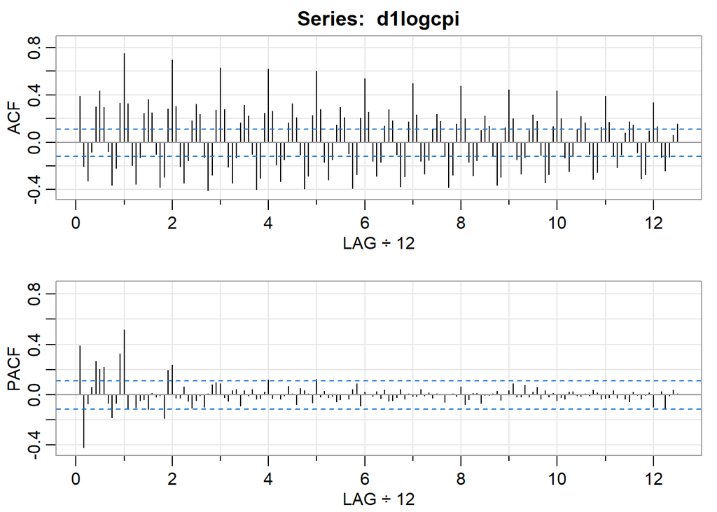

```r
# seasonal part: acf and pacf tail off => seasonal ARMA(1,1)
# non-seasonal part: acf tails off; pacf 在前兩期 seasonal lag 左側有一期顯著 => AR(1)
fit00 <- stats::arima(logcpi, order=c(1,1,0), seasonal=list(order=c(1,0,1), period=12), method = "CSS-ML")
fit00 # 係數都有顯著
```

```
##
## Call:
## stats::arima(x = logcpi, order = c(1, 1, 0), seasonal = list(order = c(1, 0,
##     1), period = 12), method = "CSS-ML")
##
## Coefficients:
##          ar1    sar1     sma1
##       0.2902  0.9899  -0.6709
## s.e.  0.0582  0.0050   0.0580
##
## sigma^2 estimated as 1.016e-06:  log likelihood = 1690.59,  aic = -3373.18
```

```r
# seasonal part: acf and pacf tail off => seasonal ARMA(1,1)
# non-seasonal part: acf 在seasonal 左右各有一期顯著 => MA(1)
fit01 <- stats::arima(logcpi, order=c(0,1,1), seasonal=list(order=c(1,0,1), period=12), method = "CSS-ML")
fit01 # 係數都有顯著
```

```
##
## Call:
## stats::arima(x = logcpi, order = c(0, 1, 1), seasonal = list(order = c(1, 0,
##     1), period = 12), method = "CSS-ML")
##
## Coefficients:
##          ma1    sar1     sma1
##       0.2470  0.9899  -0.6477
## s.e.  0.0543  0.0049   0.0580
##
## sigma^2 estimated as 1.026e-06:  log likelihood = 1688.5,  aic = -3369
```

```r
# seasonal part: acf and pacf tail off => seasonal ARMA(1,1)
# non-seasonal part: acf and pacf tail off => ARMA(1,1)
fit02 <- stats::arima(logcpi, order=c(1,1,1), seasonal=list(order=c(1,0,1), period=12), method = "CSS-ML")
fit02 # 係數都有顯著
```

```
##
## Call:
## stats::arima(x = logcpi, order = c(1, 1, 1), seasonal = list(order = c(1, 0,
##     1), period = 12), method = "CSS-ML")
##
## Coefficients:
##           ar1     ma1    sar1     sma1
##       -0.9140  0.9780  0.9899  -0.5835
## s.e.   0.0453  0.0247  0.0047   0.0605
##
## sigma^2 estimated as 1.065e-06:  log likelihood = 1682.11,  aic = -3354.22
```

```r
# seasonal part: acf tails off; pacf lag = 2 => seasonal AR(2)
# non-seasonal part: acf tails off;  pacf 在前兩期 seasonal lag 左側有一期顯著 => AR(1)
fit10 <- stats::arima(logcpi, order=c(1,1,0), seasonal=list(order=c(2,0,0), period=12), method = "CSS-ML")
fit10 # 係數都有顯著
```

```
##
## Call:
## stats::arima(x = logcpi, order = c(1, 1, 0), seasonal = list(order = c(2, 0,
##     0), period = 12), method = "CSS-ML")
##
## Coefficients:
##          ar1    sar1    sar2
##       0.2432  0.5209  0.4225
## s.e.  0.0584  0.0532  0.0539
##
## sigma^2 estimated as 1.101e-06:  log likelihood = 1679.52,  aic = -3351.05
```

```r
# seasonal part: acf tails off; pacf lag = 2 => seasonal AR(2)
# non-seasonal part: acf 在seasonal 左右各有一期顯著 => MA(1)
fit11 <- stats::arima(logcpi, order=c(0,1,1), seasonal=list(order=c(2,0,0), period=12), method = "CSS-ML")
fit11 # 係數都有顯著
```

```
##
## Call:
## stats::arima(x = logcpi, order = c(0, 1, 1), seasonal = list(order = c(2, 0,
##     0), period = 12), method = "CSS-ML")
##
## Coefficients:
##          ma1    sar1    sar2
##       0.2098  0.5334  0.4153
## s.e.  0.0547  0.0531  0.0544
##
## sigma^2 estimated as 1.107e-06:  log likelihood = 1678.18,  aic = -3348.36
```

```r
# seasonal part: acf tails off; pacf lag = 2 => seasonal AR(2)
# non-seasonal part:  acf and pacf tail off => ARMA(1,1)
fit12 <- stats::arima(logcpi, order=c(1,1,1), seasonal=list(order=c(2,0,0), period=12), method = "CSS-ML")
fit12 # 係數都有顯著
```

```
##
## Call:
## stats::arima(x = logcpi, order = c(1, 1, 1), seasonal = list(order = c(2, 0,
##     0), period = 12), method = "CSS-ML")
##
## Coefficients:
##          ar1      ma1    sar1    sar2
##       0.9624  -0.8386  0.4582  0.4520
## s.e.  0.0250   0.0461  0.0517  0.0525
##
## sigma^2 estimated as 1.03e-06:  log likelihood = 1691.67,  aic = -3373.34
```

- 方法一、差分處理 b.

```r
d12d1logcpiacf2 <- acf2(d12d1logcpi, max.lag = 150)
```

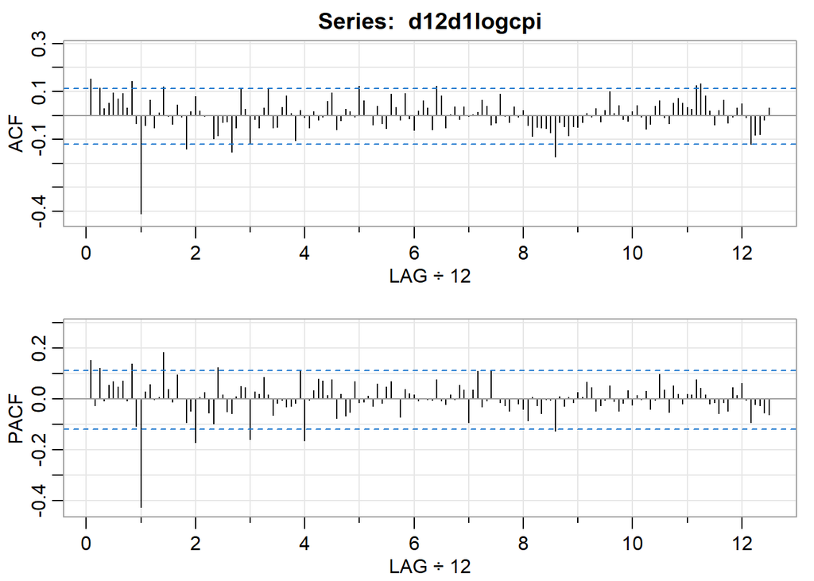

```r
# seasonal part: acf cuts off at lag = 1; pacf tails off => seasonal MA(1)
# non-seasonal part: acf 在seasonal lag = 1 左側兩期顯著; pacf tails off => MA(2)
fit20 <- stats::arima(logcpi, order=c(0,1,2), seasonal=list(order=c(0,1,1), period=12), method = "CSS-ML")
fit20 # ma2 係數不顯著，需要修正
```

```
##
## Call:
## stats::arima(x = logcpi, order = c(0, 1, 2), seasonal = list(order = c(0, 1,
##     1), period = 12), method = "CSS-ML")
##
## Coefficients:
##          ma1     ma2     sma1
##       0.2166  0.0705  -0.6452
## s.e.  0.0596  0.0586   0.0572
##
## sigma^2 estimated as 1.029e-06:  log likelihood = 1633.56,  aic = -3259.12
```

```r
fit21 <- stats::arima(logcpi, order=c(0,1,1), seasonal=list(order=c(0,1,1), period=12), method = "CSS-ML")
fit21 # 係數都有顯著
```

```
##
## Call:
## stats::arima(x = logcpi, order = c(0, 1, 1), seasonal = list(order = c(0, 1,
##     1), period = 12), method = "CSS-ML")
##
## Coefficients:
##          ma1     sma1
##       0.2189  -0.6329
## s.e.  0.0556   0.0574
##
## sigma^2 estimated as 1.036e-06:  log likelihood = 1632.83,  aic = -3259.66
```

```r
# seasonal part: acf cuts off at lag = 1; pacf tails off => seasonal MA(1)
# non-seasonal part: acf and pacf tail off => ARMA(1,1)
fit22 <- stats::arima(logcpi, order=c(1,1,1), seasonal=list(order=c(0,1,1), period=12), method = "CSS-ML")
fit22 # 係數都有顯著
```

```
##
## Call:
## stats::arima(x = logcpi, order = c(1, 1, 1), seasonal = list(order = c(0, 1,
##     1), period = 12), method = "CSS-ML")
##
## Coefficients:
##          ar1      ma1     sma1
##       0.9840  -0.8680  -0.7320
## s.e.  0.0197   0.0405   0.0502
##
## sigma^2 estimated as 9.365e-07:  log likelihood = 1646.65,  aic = -3285.29
```

```r
# seasonal part: acf and pacf tail off => seasonal ARMA(1,1)
# non-seasonal part: acf 在seasonal lag = 1 左側兩期顯著; pacf tails off => MA(2)
fit30 <- stats::arima(logcpi, order=c(0,1,2), seasonal=list(order=c(1,1,1), period=12), method = "CSS-ML")
fit30 # ma2, sar1 係數不顯著，需要修正，修正後結果為 fit21
```

```
##
## Call:
## stats::arima(x = logcpi, order = c(0, 1, 2), seasonal = list(order = c(1, 1,
##     1), period = 12), method = "CSS-ML")
##
## Coefficients:
##          ma1     ma2    sar1     sma1
##       0.2228  0.0654  0.0626  -0.6857
## s.e.  0.0603  0.0591  0.0965   0.0788
##
## sigma^2 estimated as 1.027e-06:  log likelihood = 1633.77,  aic = -3257.54
```

```r
# seasonal part: acf and pacf tail off => seasonal ARMA(1,1)
# non-seasonal part: acf and pacf tail off => ARMA(1,1)
fit31 <- stats::arima(logcpi, order=c(1,1,1), seasonal=list(order=c(1,1,1), period=12), method = "CSS-ML")
fit31 # sar1 係數不顯著，需要修正, 修正後為 fit22
```

```
##
## Call:
## stats::arima(x = logcpi, order = c(1, 1, 1), seasonal = list(order = c(1, 1,
##     1), period = 12), method = "CSS-ML")
##
## Coefficients:
##          ar1      ma1    sar1     sma1
##       0.9846  -0.8693  0.0233  -0.7452
## s.e.  0.0195   0.0408  0.0857   0.0672
##
## sigma^2 estimated as 9.36e-07:  log likelihood = 1646.68,  aic = -3283.37
```

```r
d12d1res1acf2 <- acf2(d12d1res1, max.lag = 150)
```

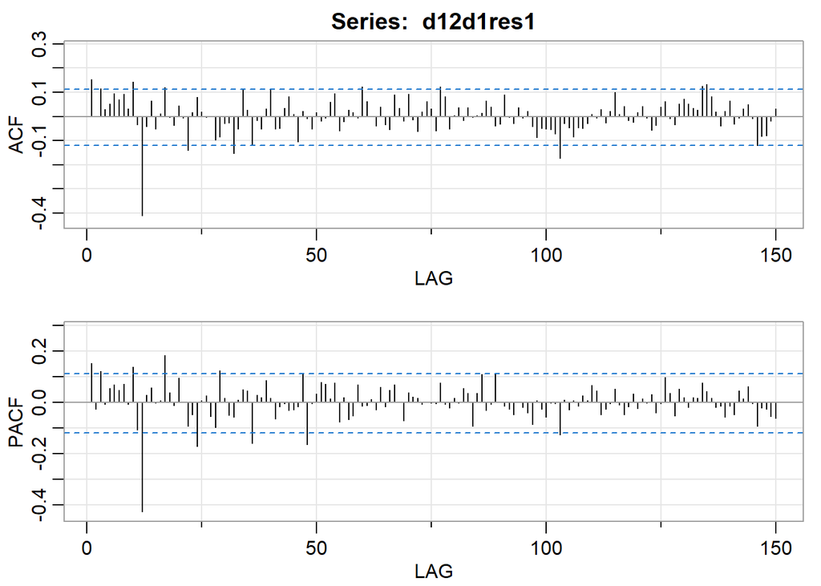

```r
# seasonal part: acf cuts off at lag = 1; pacf tails off => seasonal MA(1)
# non-seasonal part: acf 在seasonal lag = 1 左側兩期顯著; pacf tails off => MA(2)
fit40 <- stats::arima(res1, order=c(0,1,2), seasonal=list(order=c(0,1,1), period=12), method = "CSS-ML")
fit40 # ma2 係數不顯著，需要修正
```

```
##
## Call:
## stats::arima(x = res1, order = c(0, 1, 2), seasonal = list(order = c(0, 1, 1),
##     period = 12), method = "CSS-ML")
##
## Coefficients:
##          ma1     ma2     sma1
##       0.2178  0.0706  -0.6494
## s.e.  0.0595  0.0585   0.0568
##
## sigma^2 estimated as 1.025e-06:  log likelihood = 1634.1,  aic = -3260.21
```

```r
fit41 <- stats::arima(res1, order=c(0,1,1), seasonal=list(order=c(0,1,1), period=12), method = "CSS-ML")
fit41 # 係數都有顯著
```

```
##
## Call:
## stats::arima(x = res1, order = c(0, 1, 1), seasonal = list(order = c(0, 1, 1),
##     period = 12), method = "CSS-ML")
##
## Coefficients:
##          ma1     sma1
##       0.2199  -0.6371
## s.e.  0.0555   0.0570
##
## sigma^2 estimated as 1.032e-06:  log likelihood = 1633.37,  aic = -3260.74
```

```r
# seasonal part: acf cuts off at lag = 1; pacf tails off => seasonal MA(1)
# non-seasonal part: acf and pacf tail off => ARMA(1,1)
fit42 <- stats::arima(res1, order=c(1,1,1), seasonal=list(order=c(0,1,1), period=12), method = "CSS-ML")
fit42 # 係數都有顯著
```

```
##
## Call:
## stats::arima(x = res1, order = c(1, 1, 1), seasonal = list(order = c(0, 1, 1),
##     period = 12), method = "CSS-ML")
##
## Coefficients:
##          ar1      ma1     sma1
##       0.9819  -0.8661  -0.7334
## s.e.  0.0215   0.0425   0.0501
##
## sigma^2 estimated as 9.358e-07:  log likelihood = 1646.74,  aic = -3285.47
```

```r
# seasonal part: acf and pacf tail off => seasonal ARMA(1,1)
# non-seasonal part: acf 在seasonal lag = 1 左側兩期顯著; pacf tails off => MA(2)
fit50 <- stats::arima(res1, order=c(0,1,2), seasonal=list(order=c(1,1,1), period=12), method = "CSS-ML")
fit50 # ma2, sar1 係數不顯著，需要修正，修正後結果為 fit41
```

```
##
## Call:
## stats::arima(x = res1, order = c(0, 1, 2), seasonal = list(order = c(1, 1, 1),
##     period = 12), method = "CSS-ML")
##
## Coefficients:
##          ma1     ma2    sar1     sma1
##       0.2240  0.0655  0.0624  -0.6893
## s.e.  0.0602  0.0589  0.0958   0.0778
##
## sigma^2 estimated as 1.023e-06:  log likelihood = 1634.31,  aic = -3258.62
```